# 02: Time Series Features

Herman Yu

# Setup

## Libraries and Global Variables

```r
options(scipen=999)
DATA_DIR <- Sys.getenv("DATA_DIR")
DATA_PATH <- paste0(DATA_DIR, "/store-sales-time-series/train.csv")

library(fpp3)
library(readr)
library(DT)
library(scales)
```

## Load Data

```r
# The store sales data set has 1 record
# per date x family x store_nbr.
df <- read_csv(DATA_PATH) %>%
  as_tsibble(
    key = c(family, store_nbr),
    index = date
  ) %>%
  select(
    -c(
      id
    )
  )
```

```r
# check how many days into future we need to forecast
# for the test data set
df_submit <- read_csv(paste0(DATA_DIR, "/store-sales-time-series/test.csv"))

df_submit %>%
  summarise(
    start_date = min(date),
    end_date = max(date)
  )
```

```
## # A tibble: 1 × 2
##   start_date end_date
##   <date>     <date>
## 1 2017-08-16 2017-08-31
```

# Data Preparation

```r
# Submission data asks us  to forecast 16 days ahead
# from 8/15/2017 to 8/31/2017.
# We do a train-test split so that the test set
# is also exactly 16 days
train_test_split_date <- "2017-07-30"

df_train <- df %>%
  filter(
    date <= train_test_split_date
  ) %>%
  fill_gaps(sales = 0)

df_test <- df %>%
  filter(
    date > train_test_split_date
  )

h_length <- df_test %>%
  distinct(date) %>%
  pull() %>%
  length()
```

# Autocorrelations

## By Family

Certain families only start having sales numbers after a certain date in time. For these families, the leading 0’s in the `sales` variable will cause seasonal autocorrelations of be severly overestimated. The easiest solution is to filter down to a smaller time frame, say 2017-01-01 onward. This restriction will prevent us from observing any yearly patterns, but should highlight any weekly and monthly patterns.

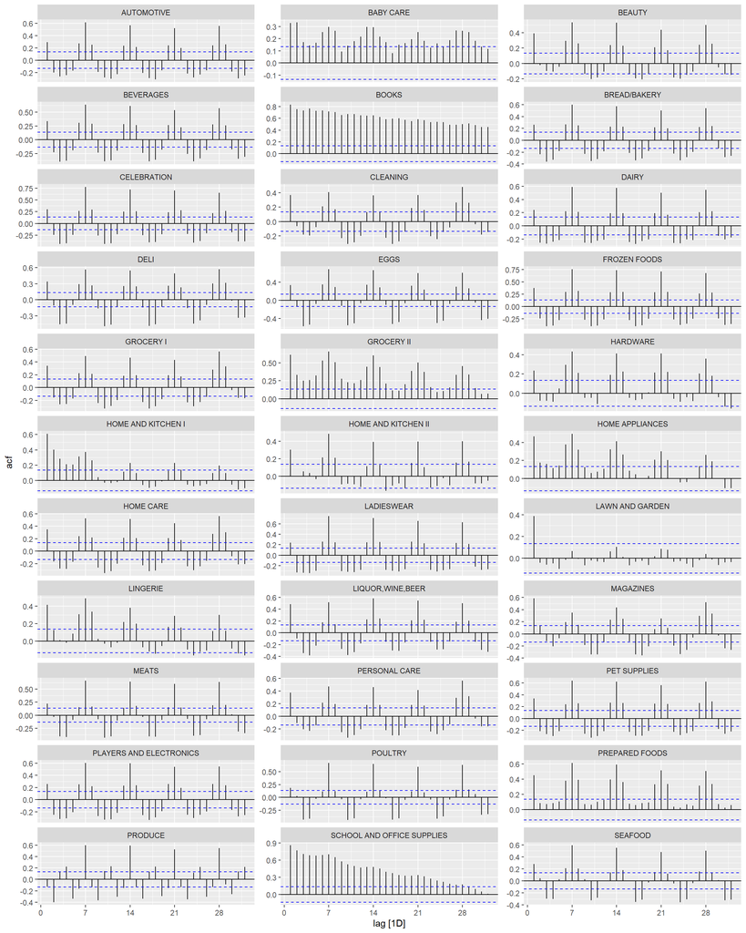

```r
df_train %>%
  filter(
    date >= "2017-01-01"
  ) %>%
  group_by(family) %>%
  summarise(
    sales = sum(sales)
  ) %>%
  ACF(sales, lag_max = 32) %>%
  autoplot() +
  facet_wrap(~family, ncol = 3, scales = "free_y")
```

## By Store

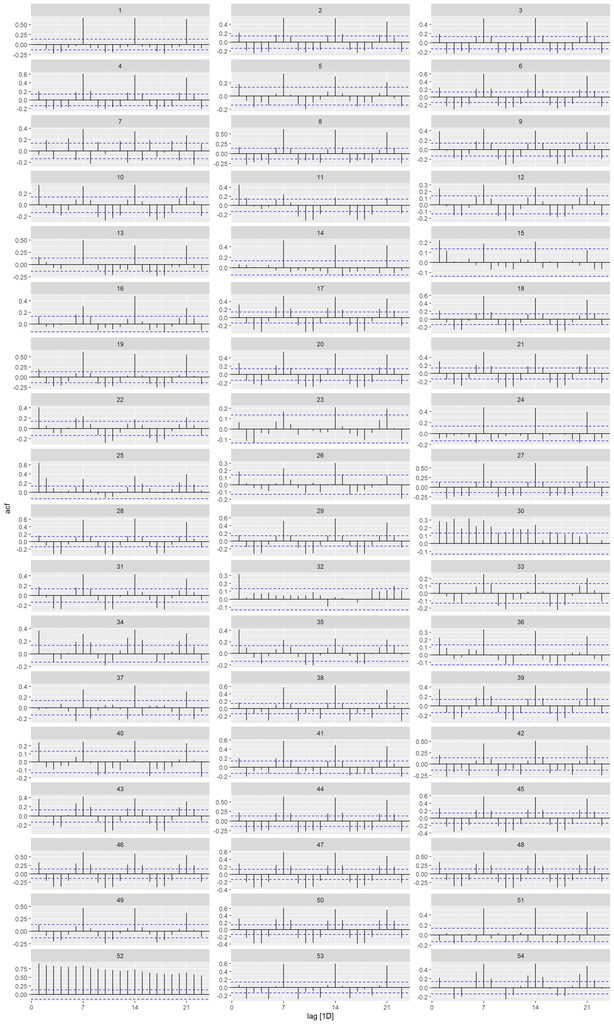

```r
df_train %>%
  filter(date >= "2017-01-01") %>%
  group_by(store_nbr) %>%
  summarise(
    sales = sum(sales)
  ) %>%
  ACF(sales) %>%
  autoplot() +
  facet_wrap(~store_nbr, ncol = 3, scales = "free_y")
```

Notes: * Store sales exhibit the same autocorrelation behavior as products. This indicates that sales generally are trended with heavy weekly seasonality.

# Trends

## By Family

### Linear Trends

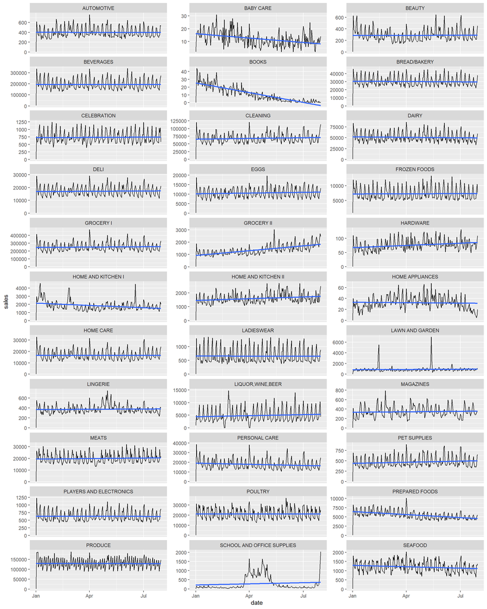

```r
df_train %>%
  filter(
    date >= "2017-01-01"
  ) %>%
  group_by(family) %>%
  summarise(
    sales = sum(sales)
  ) %>%
  as_tibble() %>%
  ggplot(aes(date, sales)) +
  geom_line() +
  geom_smooth(method = lm, se = FALSE) +
  facet_wrap(~family, ncol = 3, scales = "free_y")
```

Notes: * Many families seem relatively stationary with little trend. * Books seem to follow an exponentially decaying trend. * Home Appliances seem to have a quadratic trend. * School supplies seem to have a relatively flat trend, but is skewed by a sudden increase near the end of July (likely due to back-to-school shopping).

### Moving Average Window (KNN)

Alternatively, we can fit a non-linear trend using a moving average window of size $k$; this is equivalent to $k$-nearest neighbors. Since moving average windows fit on local neighborhoods, this method is will not be severely biased by the leading 0’s in the time series (so no need to filter).

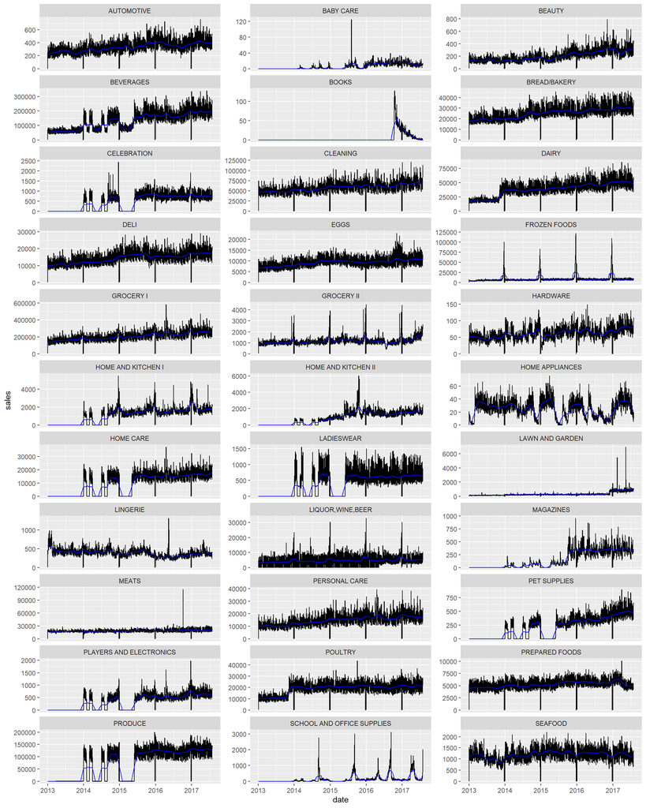

```r
window_margin = 30

df_train %>%
  group_by(family) %>%
  summarise(
    sales = sum(sales)
  ) %>%
  group_by(family) %>%
  mutate(
    trend_est = slider::slide_dbl(
      .x = sales,
      .f = mean,
      .before = window_margin,
      .after = window_margin
    )
  ) %>%
  ungroup() %>%
  as_tibble() %>%
  ggplot(aes(date, sales)) +
  geom_line() +
  geom_line(aes(y = trend_est), color = "blue") +
  facet_wrap(~family, ncol = 3, scales = "free_y")
```

## By Store

### Linear Trends

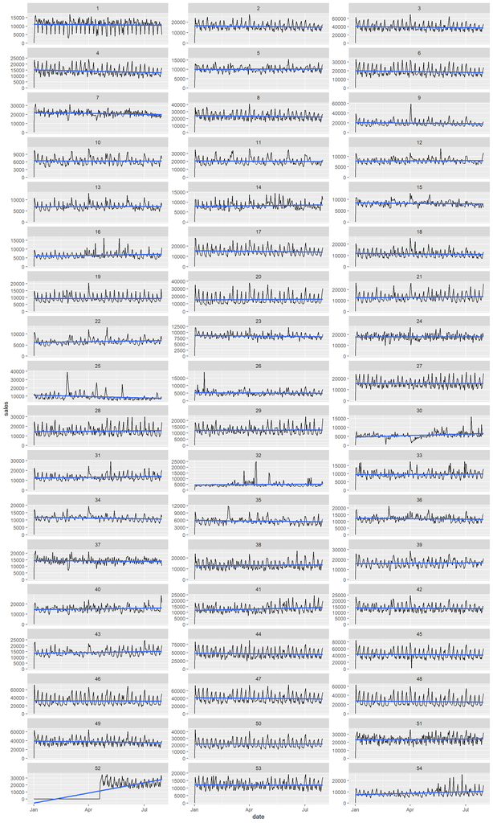

```r
df_train %>%
  filter(
    date >= "2017-01-01"
  ) %>%
  group_by(store_nbr) %>%
  summarise(
    sales = sum(sales)
  ) %>%
  as_tibble() %>%
  ggplot(aes(date, sales)) +
  geom_line() +
  geom_smooth(method = lm, se = FALSE) +
  facet_wrap(~store_nbr, ncol = 3, scales = "free_y")
```

Notes: * Trends for stores are relatively flat. Store 52 has leading zeros from January 2017 through April 2017, which is skewing the trend line up.

### Moving Average Window (KNN)

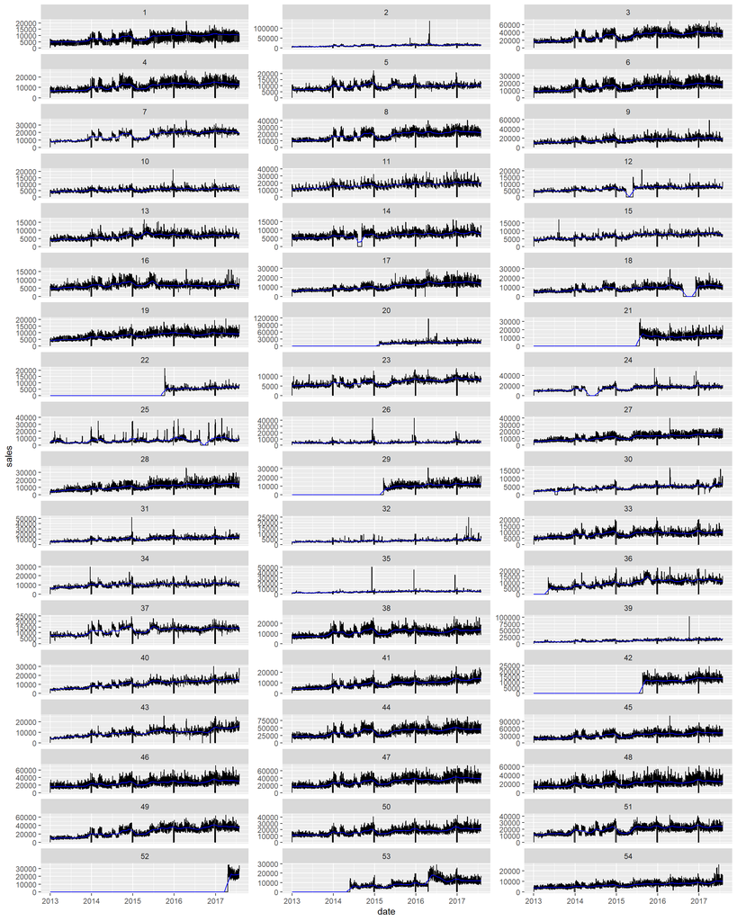

```r
window_margin = 30

df_train %>%
  group_by(store_nbr) %>%
  summarise(
    sales = sum(sales)
  ) %>%
  group_by(store_nbr) %>%
  mutate(
    trend_est = slider::slide_dbl(
      .x = sales,
      .f = mean,
      .before = window_margin,
      .after = window_margin
    )
  ) %>%
  ungroup() %>%
  as_tibble() %>%
  ggplot(aes(date, sales)) +
  geom_line() +
  geom_line(aes(y = trend_est), color = "blue") +
  facet_wrap(~store_nbr, ncol = 3, scales = "free_y")
```

# Seasonality

## By Family

We start by de-trending each time series by first estimating the trend via a moving average window. The autocorrelation plot of the resulting de-trended series should indicate the presence of seasonal patterns.

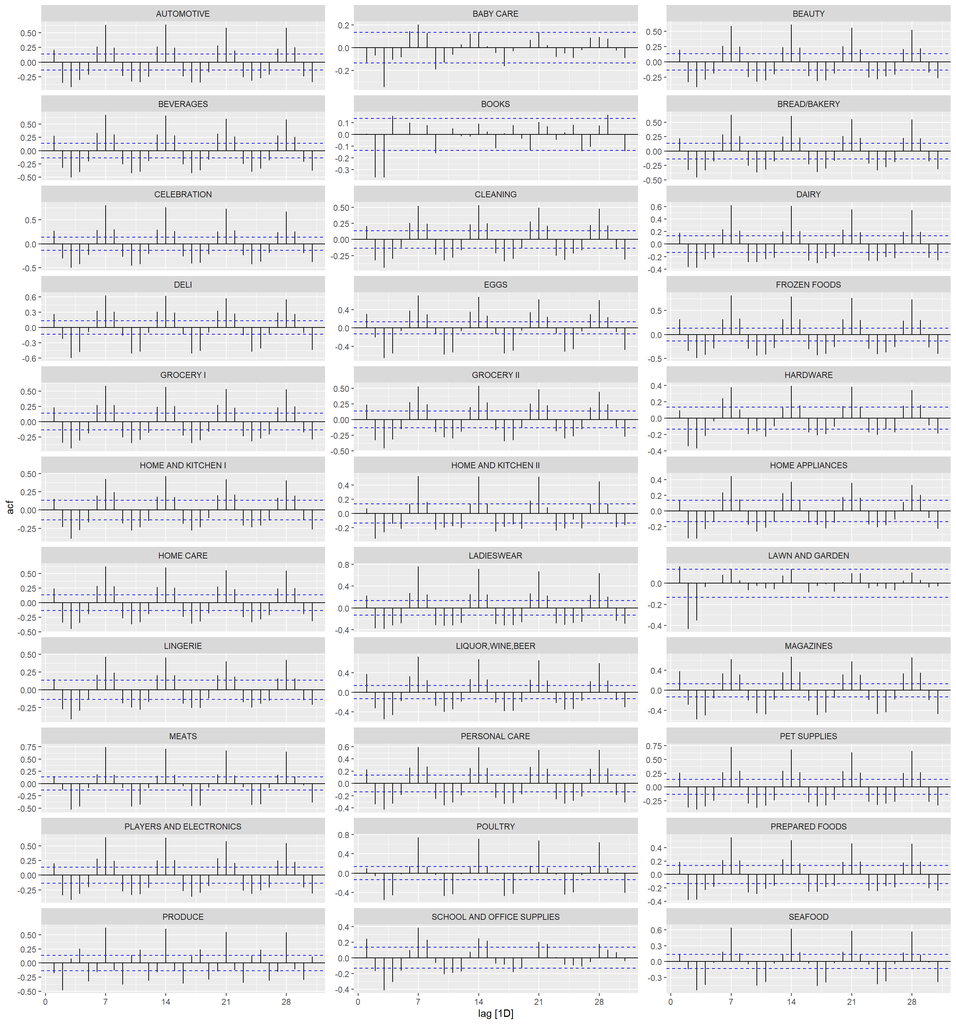

```r
# window size used for de-trending should be
# equal to the periodicity of
# the hypothesized seasonal pattern;
# since we suspect weekly seasonality, the window
# should be t-3, ..., t, ..., t+3
window_margin = 3

df_train %>%
  filter(
    date >= "2017-01-01"
  ) %>%
  group_by(family) %>%
  summarise(
    sales = sum(sales)
  ) %>%
  group_by(family) %>%
  mutate(
    trend_est = slider::slide_dbl(
      .x = sales,
      .f = mean,
      .before = window_margin,
      .after = window_margin
    ),
    sales_detrended = sales - trend_est
  ) %>%
  ungroup() %>%
  ACF(sales_detrended, lag_max = 31) %>%
  autoplot() +
  facet_wrap(~family, ncol = 3, scales = "free_y")
```

## By Store

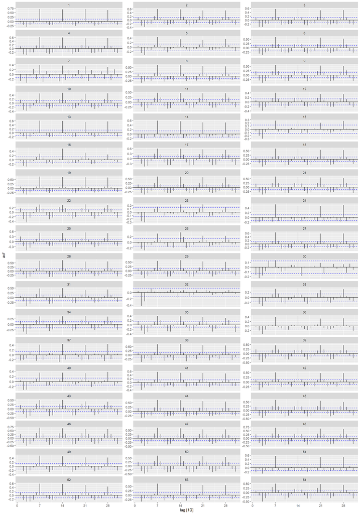

```r
# window size used for de-trending should be
# equal to the periodicity of
# the hypothesized seasonal pattern;
# since we suspect weekly seasonality, the window
# should be t-3, ..., t, ..., t+3
window_margin = 3

df_train %>%
  filter(
    date >= "2017-01-01"
  ) %>%
  group_by(store_nbr) %>%
  summarise(
    sales = sum(sales)
  ) %>%
  group_by(store_nbr) %>%
  mutate(
    trend_est = slider::slide_dbl(
      .x = sales,
      .f = mean,
      .before = window_margin,
      .after = window_margin
    ),
    sales_detrended = sales - trend_est
  ) %>%
  ungroup() %>%
  ACF(sales_detrended, lag_max = 31) %>%
  autoplot() +
  facet_wrap(~store_nbr, ncol = 3, scales = "free_y")
```

Notes: * The autocorrelations with lag 1 have disappeared for almost every store. * The spikes at lag 7, 14, 21, etc. indicate a strong weekly seasonality.